# Introduction to `scater`: Single-cell analysis toolkit for expression in R

Davis McCarthy

2015-06-15

This document gives an introduction to and overview of the functionality of the `scater` package.

The `scater` package is contains tools to help with the analysis of single-cell transcriptomic data, with the focus on RNA-seq data. The package features:

- A data structure for single-cell expression data;
- Wrappers to [`kallisto`](http://pachterlab.github.io/kallisto/) for rapid quantification of transcript abundance and tight integration with `scater`;
- Simple calculation of many quality control metrics from the expression data;
- Many tools for visualising scRNA-seq data, especially diagnostic plots for quality control;
- Subsetting and many other methods for filtering out problematic cells and features;
- Methods for identifying important experimental variables and normalising data ahead of downstream statistical analysis and modeling.

Future versions of `scater` may also incorporate:

- Methods for identifying cells at different stages of the cell cycle;
- Differential testing methods for finding features with differences in behaviour between experimental conditions.

To get up and running as quickly as possible, see the Quick Start section below. For see the various in-depth sections on various aspects of the functionality that follow.

## Quick Start

Assuming you have a matrix containing expression count data summarised at the level of some features (gene, exon, region, etc.), then we first need to form an `SCESet` object containing the data. An `SCESet` object is the basic data container that we use in `scater`.

Here we use the example data provided with the package, which gives us two objects, a matrix of counts and a dataframe with information about the cells we are studying:

```r
library(scater)
data("sc_example_counts")
data("sc_example_cell_info")
ls()
```

```
##  [1] "calculateQCMetrics"       "ex_sceset"
##  [3] "example_sceset"           "fd"
##  [5] "feature_set_1"            "findImportantPCs"
##  [7] "gene_df"                  "keep_feature"
##  [9] "keep_gene"                "multiplot"
## [11] "p1"                       "p2"
## [13] "p3"                       "p4"
## [15] "pd"                       "plot.diamonds"
## [17] "plot.mpg"                 "plotExplanatoryVariables"
## [19] "plotExpressionDefault"    "plotExpressionSCESet"
## [21] "plotExprsMeanVsFreq"      "plotFeatureData"
## [23] "plotHighestExprs"         "plotMetadata"
## [25] "plotPCASCESet"            "plotPhenoData"
## [27] "plotQC"                   "plotReducedDim.default"
## [29] "plotReducedDim.SCESet"    "plotSCESet"
## [31] "sc_example_cell_info"     "sc_example_counts"
## [33] "use_as_exprs"             "varx"
```

We use these objects to form an `SCESet` object containing all of the necessary information for our analysis:

```r
pd <- new("AnnotatedDataFrame", data = sc_example_cell_info)
rownames(pd) <- pd$Cell
example_sceset <- newSCESet(countData = sc_example_counts, phenoData = pd)
```

```
## Generating log2(counts-per-million) from counts to use as
##                 expression data, with prior.count = logExprsOffset. See edgeR::cpm().
##                         Note that counts-per-million are not recommended for most analyses.
##                         Consider using transcripts-per-million instead. See ?calculateTPM.
## Defining 'is_exprs' using count data and a lower count threshold of 0
```

```r
example_sceset
```

```
## SCESet (storageMode: environment)
## assayData: 2000 features, 40 samples
##   element names: counts, exprs, is_exprs
## protocolData: none
## phenoData
##   sampleNames: Cell_001 Cell_002 ... Cell_040 (40 total)
##   varLabels: Cell Mutation_Status Cell_Cycle Treatment
##   varMetadata: labelDescription
## featureData: none
## experimentData: use 'experimentData(object)'
## Annotation:
```

Subsetting is very convenient with this class. For example, we can filter out features that are not expressed in any cells:

```r
keep_feature <- rowSums(is_exprs(example_sceset)) > 0
example_sceset <- example_sceset[keep_feature,]
```

Now we have the expression data neatly stored in a structure that can be used for lots of exciting analyses.

## A note on terminology

The capabilities of `scater` are built on top of Bioconductor’s `Biobase`, which ties us to some specific terminology. Some of this terminology may be unfamiliar or seem peculiar for the single-cell RNA-seq setting `scater` is designed for.

In Bioconductor terminology we assay numerous “features” for a number of “samples”.

Features, in the context of `scater`, correspond most commonly to genes or transcripts, but could be any general genomic or transcriptomic regions (e.g. exon) of interest for which we take measurements. Thus, a command such as `featureNames`, returns the names of the features defined for an `SCESet` object, which in typical `scater` usage could correspond to gene IDs. In much of what follows, it may be more intuitive to mentally replace “feature” with “gene” or “transcript” (depending on the context of the study) wherever “feature” appears.

In the `scater` context, “samples” refer to individual cells that we have assayed. This differs from common usage of “sample” in other contexts, where we might usually use “sample” to refer to an individual subject, a biological replicate or similar. A “sample” in this sense in `scater` may be referred to as a “block” in the more classical statistical sense. Within a “block” (e.g. individual) we may have assayed numerous cells. Thus, the function `sampleNames`, when applied to an `SCESet` object returns the cell IDs.

## The SCESet class and methods

In `scater` we organise single-cell expression data in objects of the `SCESet` class. The class is derived from the Bioconductor `ExpressionSet` class, which provides a common interface familiar to those who have analyzed microarray experiments with Bioconductor. The class requires three input files: 1. `exprs`, a numeric matrix of expression values, where rows are features, and columns are cells 2. `phenoData`, an `AnnotatedDataFrame` object, where rows are cells, and columns are cell attributes (such as cell type, culture condition, day captured, etc.) 3. `featureData`, an `AnnotatedDataFrame` object, where rows are features (e.g. genes), and columns are feature attributes, such as biotype, gc content, etc.

The requirements for the `SCESet` class (as with other S4 classes in R and Bioconductor) are strict. The idea is that strictness with generating a valid class object ensures that downstream methods applied to the class will work reliably. Thus, the expression value matrix *must* have the same number of columns as the `phenoData` object has rows, and it must have the same number of rows as the `featureData` dataframe has rows. Row names of the `phenoData` object need to match the column names of the expression matrix. Row names of the `featureData` object need to match row names of the expression matrix.

You can create a new `SCESet` object using count data as follows. In this case, the `exprs` slot in the object will be generated as log2(counts-per-million) using the `cpm` function from `edgeR`, with a “prior count” value of 1:

```r
pd <- new("AnnotatedDataFrame", data = sc_example_cell_info)
rownames(pd) <- pd$Cell
gene_df <- data.frame(Gene = rownames(sc_example_counts))
rownames(gene_df) <- gene_df$Gene
fd <- new("AnnotatedDataFrame", data = gene_df)
example_sceset <- newSCESet(countData = sc_example_counts, phenoData = pd,
                            featureData = fd)
```

```
## Generating log2(counts-per-million) from counts to use as
##                 expression data, with prior.count = logExprsOffset. See edgeR::cpm().
##                         Note that counts-per-million are not recommended for most analyses.
##                         Consider using transcripts-per-million instead. See ?calculateTPM.
## Defining 'is_exprs' using count data and a lower count threshold of 0
```

```r
example_sceset
```

```
## SCESet (storageMode: environment)
## assayData: 2000 features, 40 samples
##   element names: counts, exprs, is_exprs
## protocolData: none
## phenoData
##   sampleNames: Cell_001 Cell_002 ... Cell_040 (40 total)
##   varLabels: Cell Mutation_Status Cell_Cycle Treatment
##   varMetadata: labelDescription
## featureData
##   featureNames: Gene_0001 Gene_0002 ... Gene_2000 (2000 total)
##   fvarLabels: Gene
##   fvarMetadata: labelDescription
## experimentData: use 'experimentData(object)'
## Annotation:
```

We can also make an `SCESet` object with just a matrix of expression values (no count data required) like this:

```r
example2 <- newSCESet(exprsData = edgeR::cpm.default(sc_example_counts))
```

```
## Defining 'is_exprs' using exprsData and a lower exprs threshold of 0
```

```r
pData(example2)
```

```
## data frame with 0 columns and 40 rows
```

```r
fData(example2)
```

```
## data frame with 0 columns and 2000 rows
```

We have accessor functions to access elements of the `SCESet` object:

- `counts(object)`: returns the matrix of read counts. As you can see above, if no counts are defined for the object, then the counts matrix slot is simpy `NULL`.

```r
counts(example2)[1:3, 1:6]
```

[output not shown]

- `exprs(object)`: returns the matrix of feature expression values. Typically these should be log2(counts-per-million) values or log2(reads-per-kilobase-per-million-mapped), appropriately normalised of course. The package will generally assume that these are the values to use for expression.

```r
exprs(example2)[1:3, 1:6]
```

```
##           Cell_001 Cell_002 Cell_003 Cell_004 Cell_005 Cell_006
## Gene_0001     0.00 749.5293 6.561271    0.000    0.000   0.0000
## Gene_0002  1344.85 396.0927 9.841906 5558.424 2826.476 923.5422
## Gene_0003     0.00   0.0000 0.000000    0.000 1483.563   0.0000
```

- `is_exprs(object)`: returns a logical matrix indicating whether each feature expression observation is above the defined `lowerDetectionLimit` (default is 0). This can be determined on the count scale or the “expression” (i.e. `exprs(object)`) scale.

```r
is_exprs(example2)[1:3, 1:6]
```

```
##           Cell_001 Cell_002 Cell_003 Cell_004 Cell_005 Cell_006
## Gene_0001    FALSE     TRUE     TRUE    FALSE    FALSE    FALSE
## Gene_0002     TRUE     TRUE     TRUE     TRUE     TRUE     TRUE
## Gene_0003    FALSE    FALSE    FALSE    FALSE     TRUE    FALSE
```

It is straight-forward to change the threshold by which we decide which observations are expressed or not:

```r
is_exprs(example2) <- calcIsExprs(example2, lowerDetectionLimit = 100,
                               exprs_data = "exprs")
is_exprs(example2)[1:3, 1:6]
```

```
##           Cell_001 Cell_002 Cell_003 Cell_004 Cell_005 Cell_006
## Gene_0001    FALSE     TRUE    FALSE    FALSE    FALSE    FALSE
## Gene_0002     TRUE     TRUE    FALSE     TRUE     TRUE     TRUE
## Gene_0003    FALSE    FALSE    FALSE    FALSE     TRUE    FALSE
```

If you later find some count data that you want to add to the `SCESet` object (always worth checking down the back of the couch), then you can add it easily:

```r
counts(example2) <- sc_example_counts
example2
```

```
## SCESet (storageMode: environment)
## assayData: 2000 features, 40 samples
##   element names: counts, exprs, is_exprs
## protocolData: none
## phenoData: none
## featureData: none
## experimentData: use 'experimentData(object)'
## Annotation:
```

```r
counts(example2)[1:3, 1:6]
```

```
##           Cell_001 Cell_002 Cell_003 Cell_004 Cell_005 Cell_006
## Gene_0001        0      123        2        0        0        0
## Gene_0002      575       65        3     1561     2311      160
## Gene_0003        0        0        0        0     1213        0
```

Handily, it is also easy to replace other data in slots of the `SCESet` object using generic accessor and replacement functions.

```r
gene_df <- data.frame(Gene = rownames(sc_example_counts))
rownames(gene_df) <- gene_df$Gene
fd <- new("AnnotatedDataFrame", data = gene_df)
## replace featureData
fData(example_sceset) <- fd
## replace phenotype data
pData(example_sceset) <- pd
## replace expression data to be used
exprs(example_sceset) <- edgeR::cpm.default(counts(example_sceset),
                                            prior.count = 5, log = TRUE)
```

It is possible to get an overall view of the dataset by using the `plot` method available for `SCESet` objects. This method plots the cumulative proportion of each cell’s library that is accounted for by the top highest-expressed features (by default showing the cumulative proportion across the top 500 features).

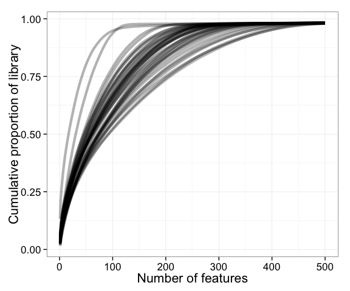

```r
plot(example_sceset)
```

This gives an overall idea of differences in expression distributions for different cells. It is used in the same way as per-sample boxplots are for microarray or bulk RNA-seq data. Due to the large numbers of zeroes in expression values for single-cell RNA-seq data, boxplots are not as useful, so instead we focus on the contributions from the most expressed features for each cell.

With this function, we can split up the cells based on phenoData variables to get a finer-grained look at differences between cells. By default, the plot method will try to use transcripts-per-million values for the plot, but if these are not present in the `SCESet` object, then the values in `exprs(object)` will be used. Other expression values can be used, specified with the `use_as_exprs` argument

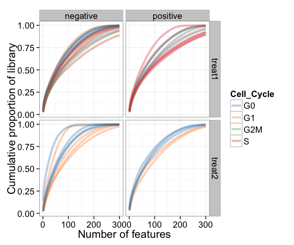

```r
plot(example_sceset, block1 = "Mutation_Status", block2 = "Treatment",
     colour_by = "Cell_Cycle", nfeatures = 300, use_as_exprs = "counts")
```

This sort of approach can help to pick up large differences in expression distributions across different experimental blocks (e.g. processing batches or similar.)

## Plots of expression values

In `scater`, the `plotExpression` function makes it easy to plot expression values for a subset of genes or features. This can be particularly useful when investigating the some features identified as being of interest from differential expression testing or other means.

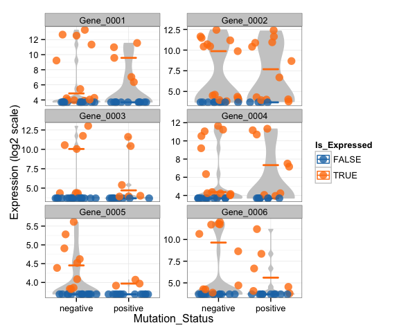

```r
plotExpression(example_sceset, rownames(example_sceset)[1:6],
               x = "Mutation_Status", use_as_expr = "exprs")
```

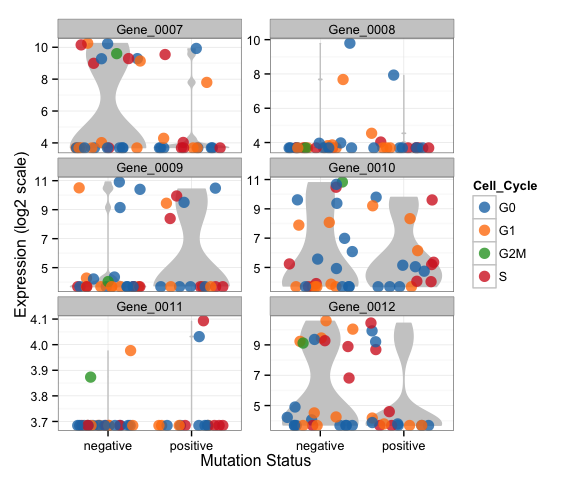

```r
plotExpression(example_sceset, rownames(example_sceset)[7:12],
               x = "Mutation_Status", use_as_expr = "exprs", colour = "Cell_Cycle",
               show_median = FALSE, show_violin = TRUE,  xlab = "Mutation Status")
```

## Quality control

The `scater` package puts a focus on aiding with quality control (QC) and pre-processing of single-cell RNA-seq data before further downstream analysis.

We see QC as consisting of three distinct steps:

1. QC and filtering of features (genes)
2. QC and filtering of cells
3. QC of experimental variables

Following QC, we can proceed with data normalisation before downstream analysis and modelling.

In the next few sections we discuss the QC and filtering capabilities available in `scater`.

### Calculate QC metrics

To compute commonly-used QC metrics we have the function `calculateQCMetrics()`:

```r
example_sceset <- calculateQCMetrics(example_sceset, feature_controls = 1:20)
varLabels(example_sceset)
```

```
##  [1] "Cell"
##  [2] "Mutation_Status"
##  [3] "Cell_Cycle"
##  [4] "Treatment"
##  [5] "depth"
##  [6] "log10_depth"
##  [7] "filter_on_depth"
##  [8] "coverage"
##  [9] "filter_on_coverage"
## [10] "exprs_from_feature_controls"
## [11] "pct_exprs_from_feature_controls"
## [12] "filter_on_pct_exprs_from_feature_controls"
## [13] "pct_exprs_from_top_50_features"
## [14] "pct_exprs_from_top_100_features"
## [15] "pct_exprs_from_top_200_features"
## [16] "counts_from_feature_controls"
## [17] "pct_counts_from_feature_controls"
## [18] "filter_on_pct_counts_from_feature_controls"
## [19] "pct_counts_from_top_50_features"
## [20] "pct_counts_from_top_100_features"
## [21] "pct_counts_from_top_200_features"
## [22] "n_detected_feature_controls"
## [23] "exprs_from_endogenous_features"
## [24] "counts_from_endogenous_features"
## [25] "log10_exprs_from_feature_controls"
## [26] "log10_counts_from_feature_controls"
## [27] "log10_exprs_from_endogenous_features"
## [28] "log10_counts_from_endogenous_features"
## [29] "is_cell_control"
```

More than one set of feature controls can be defined if desired.

```r
example_sceset <- calculateQCMetrics(
    example_sceset, feature_controls = list(controls1 = 1:20, controls2 = 500:1000),
    cell_controls = list(set_1 = 1:5, set_2 = 31:40))
varLabels(example_sceset)
```

```
##  [1] "Cell"
##  [2] "Mutation_Status"
##  [3] "Cell_Cycle"
##  [4] "Treatment"
##  [5] "depth"
##  [6] "log10_depth"
##  [7] "filter_on_depth"
##  [8] "coverage"
##  [9] "filter_on_coverage"
## [10] "exprs_from_feature_controls_controls1"
## [11] "pct_exprs_from_feature_controls_controls1"
## [12] "filter_on_pct_exprs_from_feature_controls_controls1"
## [13] "counts_from_feature_controls_controls1"
## [14] "pct_counts_from_feature_controls_controls1"
## [15] "filter_on_pct_counts_from_feature_controls_controls1"
```

[output cut: 34 more lines]

#### Cell-level QC metrics

This function adds the following columns to `pData(object)`:

- `depth`: total number of counts for the cell (aka ‘library size’)
- `log10_depth`: depth on the log10-scale
- `coverage`: the number of features for the cell that have expression above the detection limit (default detection limit is zero)
- `filter_on_depth`: would this cell be filtered out based on its log10-depth being (by default) more than 5 median absolute deviations from the median log10-depth for the dataset?
- `filter_on_coverage`: would this cell be filtered out based on its coverage being (by default) more than 5 median absolute deviations from the median coverage for the dataset?
- `counts_from_feature_controls`: total number of counts for the cell that come from (a set of user-defined) control features. Defaults to zero if no control features are indicated.
- `counts_from_endogenous_features`: total number of counts for the cell that come from endogenous features (i.e. not control features). Defaults to `depth` if no control features are indicated.
- `log10_counts_from_feature_controls`: total number of counts from control features on the log10-scale. Defaults to zero (i.e. log10(0 + 1), offset to avoid infinite values) if no control features are indicated.
- `log10_counts_from_endogenous_features`: total number of counts from endogenous features on the log10-scale. Defaults to zero (i.e. log10(0 + 1), offset to avoid infinite values) if no control features are indicated.
- `n_detected_feature_controls`: number of defined feature controls that have expression greater than the threshold defined in the object. *`pct_counts_from_feature_controls`: percentage of all counts that come from the defined control features. Defaults to zero if no control features are defined.

If we define multiple sets of feature controls, then the above will be supplied for all feature sets, plus the set of all feature controls combined, as appropriate.

Furthermore, where “counts” appear in the above, the same metrics will also be computed for “exprs”, “tpm” and “fpkm” (if tpm and fpkm are present in the `SCESet` object).

#### Feature-level QC metrics

The function further adds the following columns to `fData(object)`:

- `mean_exprs`: the mean expression level of the gene/feature.
- `exprs_rank`: the rank of the feature’s expression level in the cell.
- `total_feature_counts`: the total number of counts mapped to that feature across all cells.
- `log10_total_feature_counts`: total feature counts on the log10-scale.
- `pct_total_counts`: the percentage of all counts that are accounted for by the counts mapping to the feature.
- `is_feature_control`: is the feature a control feature? Default is `FALSE` unless control features are defined by the user.
- `n_cells_exprs`: the number of cells for which the expression level of the feature is above the detection limit (default detection limit is zero).

```r
names(fData(example_sceset))
```

```
##  [1] "Gene"                         "mean_exprs"
##  [3] "exprs_rank"                   "n_cells_exprs"
##  [5] "total_feature_exprs"          "log10_total_feature_exprs"
##  [7] "pct_total_exprs"              "total_feature_counts"
##  [9] "log10_total_feature_counts"   "pct_total_counts"
## [11] "is_feature_control_controls1" "is_feature_control_controls2"
## [13] "is_feature_control"
```

As above, where “counts” appear in the above, the same metrics will also be computed for “exprs”, “tpm” and “fpkm” (if tpm and fpkm are present in the `SCESet` object).

### Produce diagnostic plots for QC

Visualising the data and metadata in various ways can be very helpful for QC. We have a suite of plotting functions to produce diagnostic plots for: 1. Plotting the most expressed features across the dataset. 2. Finding the most important principal components for a given cell phenotype or metadata variable (from `pData(object)`). 3. Plotting a set of cell phenotype/metadata variables against each other and calculating the (marginal) percentage of feature expression variance that they explain.

These three QC plots can all be accessed through the function `plotQC` (we need to make sure there are no features with zero or constant expression).

### QC and filtering of features

The first step in the QC process is filtering out unwanted features. We will typically filter out features with very low overall expression, and any others that plots or other metrics indicate may be problematic.

First we look at a plot that shows the top 50 (by default) most-expressed features. By default, “expression” is defined using the feature counts (if available), but $tpm$, $cpm$, $fpkm$ or the `exprs` values can be used instead, if desired.

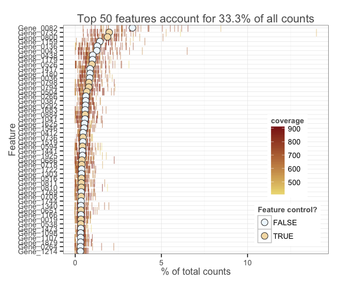

```r
keep_feature <- rowSums(is_exprs(example_sceset)) > 4
example_sceset <- example_sceset[keep_feature,]
## Plot QC
plotQC(example_sceset, type = "highest-expression")
```

```r
p1 <- plotQC(example_sceset, type = "highest-expression", use_as_exprs = "exprs")
p2 <- plotQC(example_sceset, type = "highest-expression", use_as_exprs = "tpm")
```

```
## Warning in plotHighestExprs(object, ...): The object does not contain tpm
## expression values. Using exprs(object) values instead.
```

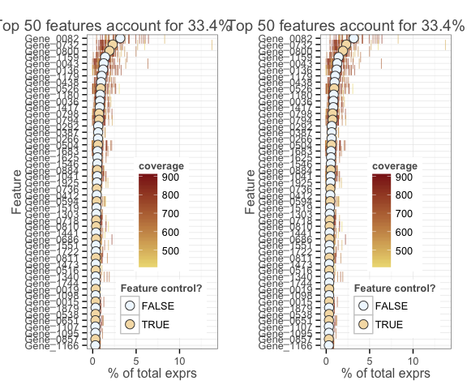

```r
multiplot(p1, p2, cols = 2)
```

As we can see in the output above, if the desired expression values are not present in the `SCESet` object (e.g. there are no $tpm$ values, above), then `exprs(object)` values will be used instead, with a warning. So in the above, we end up with the same plot twice.

The `multiplot` function allows a very simple way to plot multiple `ggplot2` plots on the same page. For more sophisticated possibilities for arranging multiple `ggplot2` plots, check out the excellent [`cowplot`](http://cran.r-project.org/web/packages/cowplot/vignettes/introduction.html) package, available on CRAN.

It can also be particularly useful to inspect the most-expressed features in just the cell controls (for example blanks or bulk samples). Subsetting capabilities for `SCESet` objects allow us to do this easily. In the previous section, we defined two sets of cell controls in the call to `calculateQCMetrics`. That function added the `is_cell_control` column to the phenotype data of the `SCESet` object `example_sceset`, which indicates if a cell is defined as a cell control across any of the cell control sets.

The `$` operator makes it easy to access the `is_cell_control` column and use it to subset the `SCESet` as below. We can compare the most-expressed features in the cell controls and in the cells of biological interest with this subsetting, as shown below.

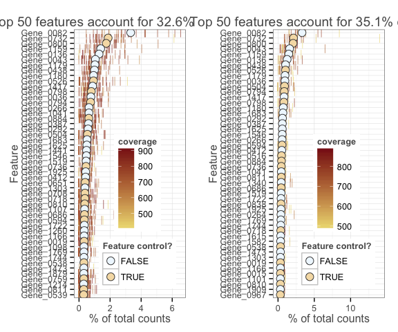

```r
p1 <- plotQC(example_sceset[, !example_sceset$is_cell_control],
             type = "highest-expression")
p2 <- plotQC(example_sceset[, example_sceset$is_cell_control],
       type = "highest-expression")
multiplot(p1, p2, cols = 2)
```

Another way to obtain an idea of the level of technical noise in the dataset is to plot the mean expression level against frequency of expression (that is, number of cells with expression for the gene above the defined threshold (default is zero)). A set of specific features to plot can be defined, but need not be. By default, the function will look for defined feature controls (as supplied to `calculateQCMetrics`). If feature controls are found, then these will be plotted, if not then all features will be plotted.

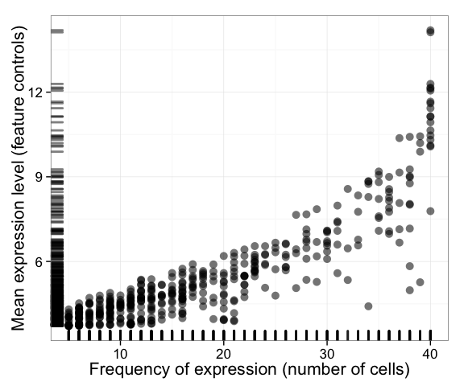

```r
plotQC(example_sceset, type = "exprs-mean-vs-freq")
```

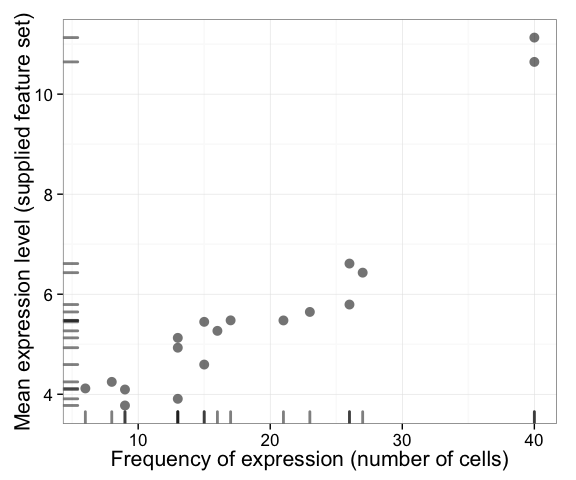

```r
feature_set_1 <- fData(example_sceset)$is_feature_control_controls1
plotQC(example_sceset, type = "exprs-mean-vs-freq", feature_set = feature_set_1)
```

Beyond these QC plots, we have a neat, general and flexible function for plotting two feature metadata variables:

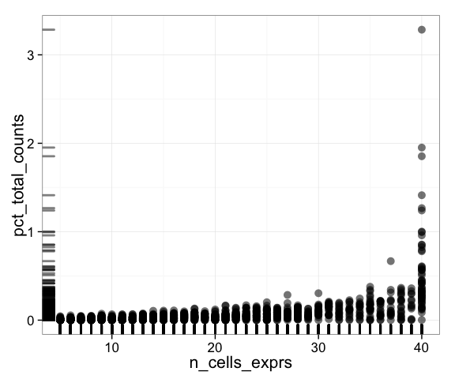

```r
plotFeatureData(example_sceset, aes(x = n_cells_exprs, y = pct_total_counts))
```

We can see that there is a small number of features that are ubiquitously expressed expressed in all cells (`n_cells_exprs`) and account for a large proportion of all counts observed (`pct_total_counts`; more than 0.5% of all counts).

The subsetting of rows of `SCESet` objects makes it easy to drop unwanted features.

### QC and filtering of cells

See `plotPhenoData` and other QC plots below. The subsetting of columns (which correspond to cells) of `SCESet` objects makes it easy to drop unwanted cells.

#### Plotting cell metadata variables

We also have neat functions to plot two cell metadata variables:

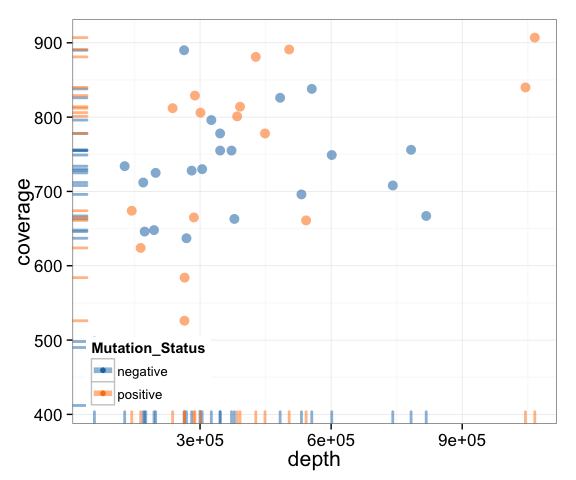

```r
plotPhenoData(example_sceset, aes(x = depth, y = coverage,
                                  colour = Mutation_Status))
```

These sorts of plots can be very useful for finding potentially problematic cells.

The output of these functions is a `ggplot` object, which can be added to, amended and altered. For example, if we don’t like the legend position in the Coverage vs Depth plot above, we can change it:

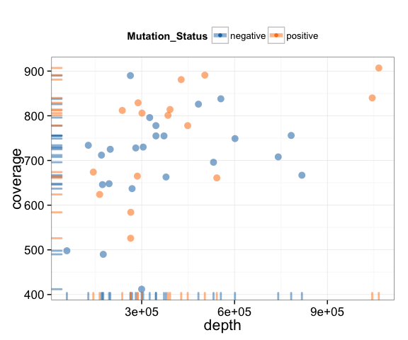

```r
plotPhenoData(example_sceset, aes(x = depth, y = coverage,
                                  colour = Mutation_Status)) +
    theme(legend.position = "top")
```

We could also add a trend line for each group:

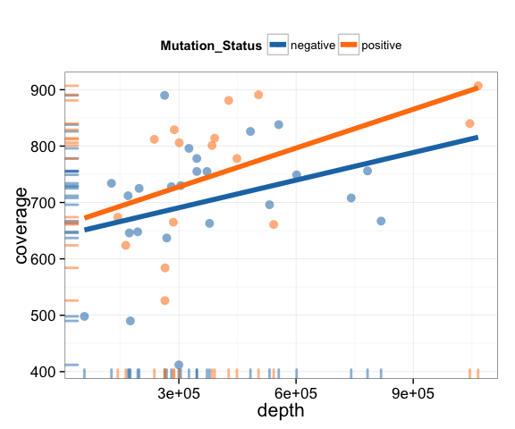

```r
plotPhenoData(example_sceset, aes(x = depth, y = coverage,
                                  colour = Mutation_Status)) +
    theme(legend.position = "top") +
    stat_smooth(method = "lm", se = FALSE, size = 2, fullrange = TRUE)
```

Tapping into the powerful capabilities of `ggplot2`, the possibilities are many.

A particularly useful plot for cell QC is plotting the percentage of expression accounted for by feature controls against coverage.

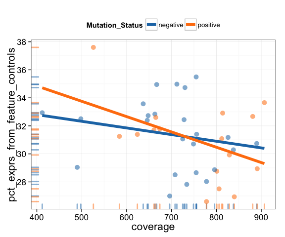

```r
plotPhenoData(example_sceset, aes(x = coverage, y = pct_exprs_from_feature_controls,
                                  colour = Mutation_Status)) +
    theme(legend.position = "top") +
    stat_smooth(method = "lm", se = FALSE, size = 2, fullrange = TRUE)
```

On real data, we expect to see well-behaved cells with relatively high coverage (number of features with detectable expression) and low percentage of expression from feature controls. High percentage expression from feature controls and low coverage are indicative of blank and failed cells.

The `plotPhenoData` function is useful for exploring the relationships between the many QC metrics computed by `calculateQCMetrics` above. Often, problematic cells can be identified from such plots.

#### PCA and dimensionality reduction

The `plotPCA` function makes it easy to produce a PCA plot directly from an `SCESet` object, which is useful for visualising cells.

The default plot shows the first two principal components and if any cell controls have been defined, plots these cells in a different colour.

```
## stand_exprs(object) was null, so standardising exprs values for PCA.
```

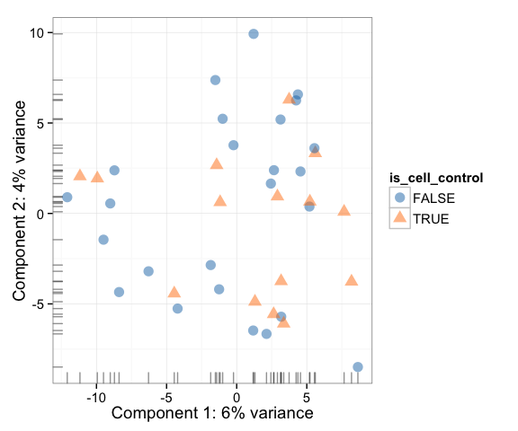

```r
plotPCA(example_sceset)
```

By default, the PCA plot is produced using the 500 features with the most variable expression across all cells. The number of most-variable features used can be changed with the `ntop` argument. Alternatively, a specific set of features to use for the PCA can be defined with the `feature_set` argument. This allows, for example, using only housekeeping features or control features to produce a PCA plot.

In the plot below, only the features defined as “feature controls” are used for the PCA.

```
## stand_exprs(object) was not null, so using these values for PCA.
```

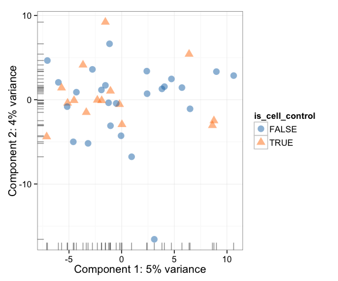

```r
plotPCA(example_sceset, feature_set = fData(example_sceset)$is_feature_control)
```

The function allows more than just the first two components to be plotted, and also allows phenotype variables to be used to define the colour, shape and size of points in the scatter plot.

```
## stand_exprs(object) was not null, so using these values for PCA.
```

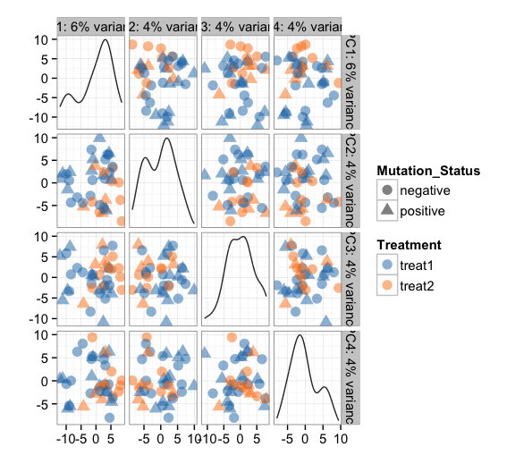

```r
plotPCA(example_sceset, ncomponents = 4, colour_by = "Treatment",
        shape_by = "Mutation_Status")
```

When more than two components are plotted, the diagonal boxes in the scatter plot matrix show the density for each component.

The `SCESet` matrix has a `reducedDimension` slot, where coordinates for a reduced dimension representation of the cells can be stored. If we so wish, the top principal components can be added to the `reducedDimension` slot:

```
## stand_exprs(object) was not null, so using these values for PCA.
```

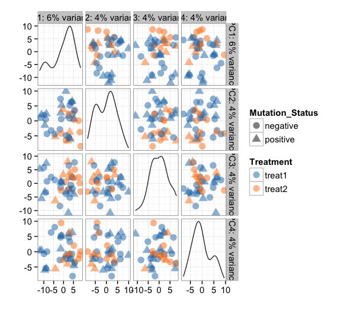

```r
example_sceset <- plotPCA(example_sceset, ncomponents = 4,
                          colour_by = "Treatment", shape_by = "Mutation_Status",
                          return_SCESet = TRUE)
```

```r
head(reducedDimension(example_sceset))
```

```
##                 PC1        PC2        PC3        PC4
## Cell_001 -11.176605  2.0532262 -5.5545027  0.4341370
## Cell_002  -1.428448  2.6701895  0.5500525  0.9448481
## Cell_003   2.905914  0.9408687 -1.9674264 -0.7710538
## Cell_004  -9.937164  1.9355382  5.8211075 -0.6894513
## Cell_005   5.605234  3.3310936  5.0907582 -3.3590816
## Cell_006  -1.852437 -2.8529658 -8.3223904 -2.7249169
```

As shown above, the function `reducedDimension` (as well as the shorthand `redDim`) can be used to access the reduced dimension coordinates.

This means that any other dimension reduction method can be applied and the coordinates stored. For example, we might wish to use t-distributed stochastic nearest neighbour embedding (t-SNE) or Gaussian process latent variable models or any other dimensionality reduction method. We can store these in the `SCESet` object and produce plots just as we did with PCA:

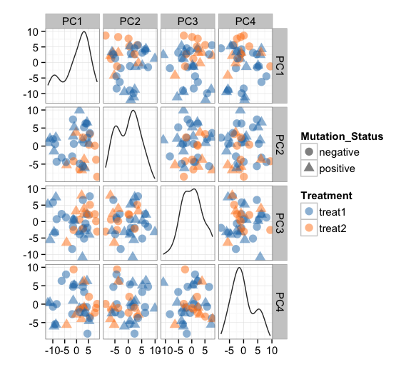

```r
plotReducedDim(example_sceset, ncomponents = 4, colour_by = "Treatment",
               shape_by = "Mutation_Status")
```

(Here, the dimensionality reduction is just PCA, so we have the same plot as the PCA plot above.)

Based on PCA or dimensionality reduction plots we may identify outlier cells and, if we wish, filter them out of the analysis.

### QC of experimental variables

See the `plotQC` options below. The various plotting functions enable visualisation of the relationship betwen experimental variables and the expression data.

We can look at the relative importance of different explanatory variables with some of the `plotQC` function options. We can compute the median marginal $R^2$ for each variable in `pData(example_sceset)` when fitting a linear model regressing `exprs` values against just that variable.

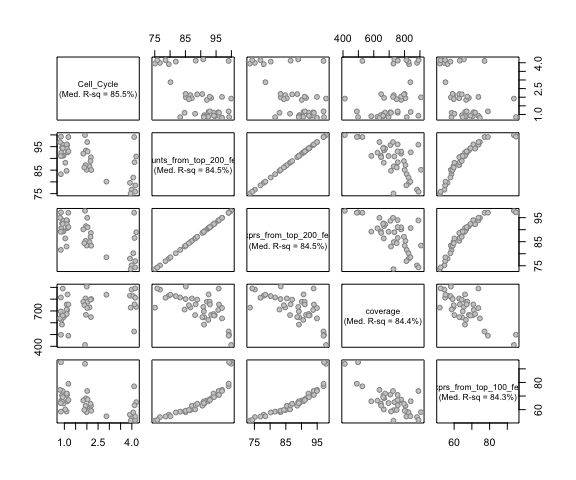

```r
plotQC(example_sceset, type = "expl")
```

Alternatively, we can choose a subset of variables to plot in this manner.

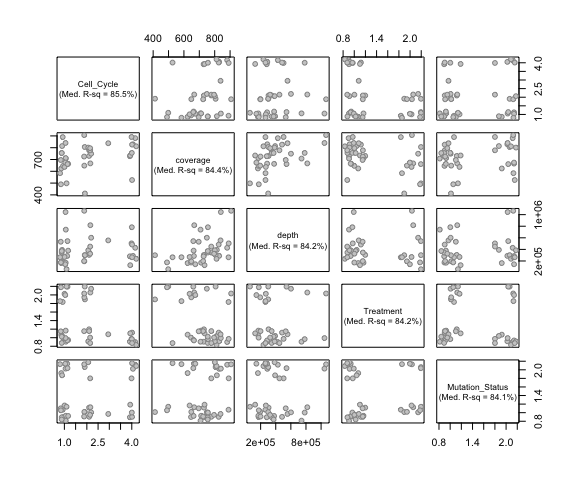

```r
plotQC(example_sceset, type = "expl",
       variables = c("coverage", "depth", "Mutation_Status", "Treatment",
                     "Cell_Cycle"))
```

We can also easily produce plots to identify PCs that correlate with experimental and QC variables of interest. The function ranks the principal components in decreasing order of $R^2$ from a linear model regressing PC value against the variable of interest.

The default behaviour is to produce a pairs plot of the top five PCs.

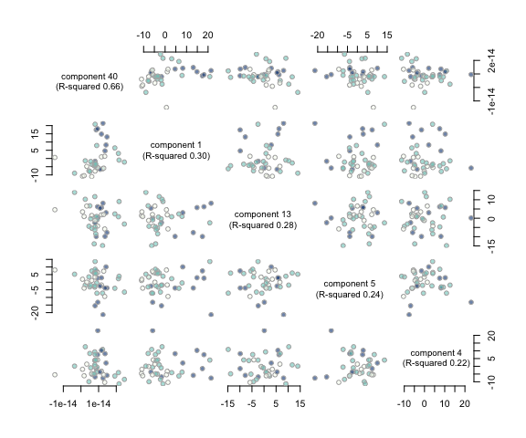

```r
plotQC(example_sceset, type = "find-pcs", variable = "coverage")
```

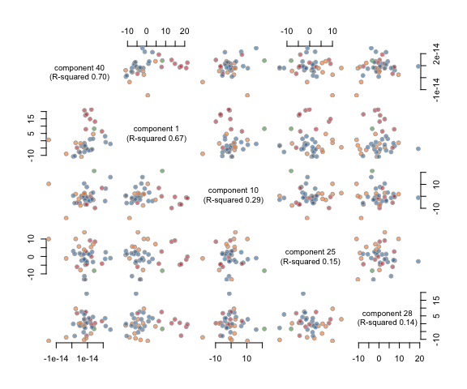

```r
plotQC(example_sceset, type = "find-pcs", variable = "Cell_Cycle")
```

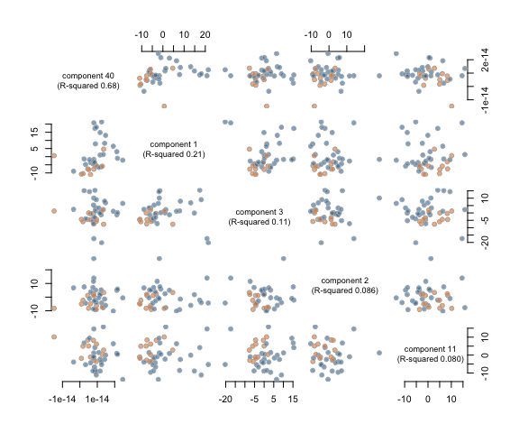

```r
plotQC(example_sceset, type = "find-pcs", variable = "Treatment")
```

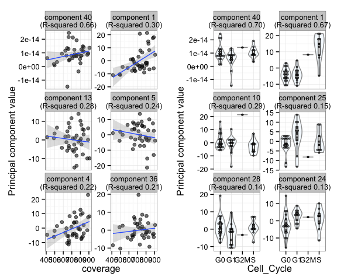

```r
p1 <- plotQC(example_sceset, type = "find-pcs", variable = "coverage",
        plot_type = "pcs-vs-vars")
p2 <- plotQC(example_sceset, type = "find-pcs", variable = "Cell_Cycle",
       plot_type = "pcs-vs-vars")
multiplot(p1, p2, cols = 2)
```

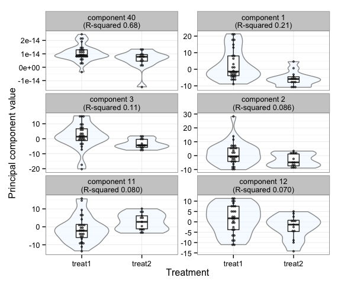

```r
plotQC(example_sceset, type = "find-pcs", variable = "Treatment",
       plot_type = "pcs-vs-vars")
```

In this small dataset depth and coverage explain a very large proportion of the variance in feature expression. The proportion of variance that they explain for a real dataset should be much smaller (say 1-5%).

Combined with the excellent subsetting capabilities of the `SCESet` class, we have convenient tools for conducting QC and pre-processing (e.g. filtering) data for downstream analysis.

## Data normalisation

We can use feature controls to help address differences between cells arising from different sets of transcripts being expressed and differences in library composition.

Important experimental variables and latent factors (if used) can be regressed out, so that normalised data has these effects removed.

## Feature and cell pairwise distance matrices

In many single-cell expression analyses we may want to generate and store pairwise distance matrices for both cells and features.

We can first look at a multidimensional scaling (MDS) plot using Euclidean distance between cells.

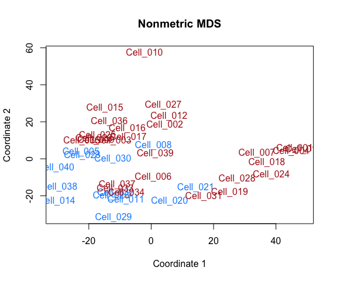

```r
cell_dist <- as.matrix(dist(t(exprs(example_sceset))))
cellPairwiseDistances(example_sceset) <- cell_dist

if(require(MASS)) {
    fit <- MASS::isoMDS(cellDist(example_sceset), k=2) # k is the number of dim
    # plot solution
    Col <- c("firebrick", "dodgerblue")[factor(pData(example_sceset)$Treatment)]
    plot(fit$points[,1:2], xlab="Coordinate 1", ylab="Coordinate 2", main="Nonmetric MDS",
         type="n")
    text(fit$points[,1:2], labels=colnames(example_sceset), col=Col)
}
```

Second, we could also look at an MDS plot using the count data and the Canberra distance metric.

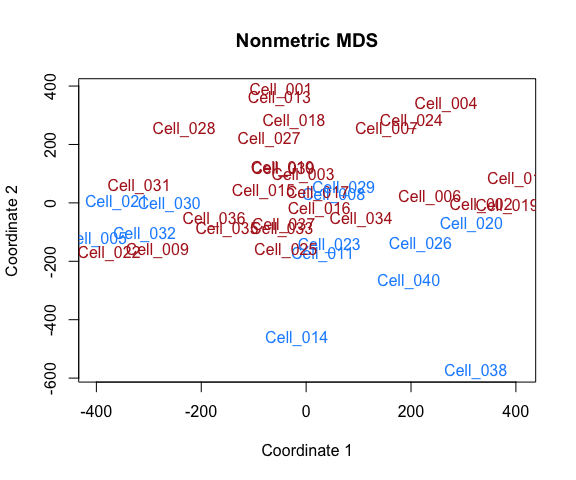

```r
cell_dist <- as.matrix(dist(t(counts(example_sceset)), method="canberra"))
cellPairwiseDistances(example_sceset) <- cell_dist

if(require(MASS)) {
    fit <- MASS::isoMDS(cellDist(example_sceset), k=2) # k is the number of dim
    # plot solution
    Col <- c("firebrick", "dodgerblue")[factor(pData(example_sceset)$Treatment)]
    plot(fit$points[,1:2], xlab="Coordinate 1", ylab="Coordinate 2", main="Nonmetric MDS",
         type="n")
    text(fit$points[,1:2], labels=colnames(example_sceset), col=Col)
}
```

We can also look at a (nonmetric) MDS plot for the features, here using Euclidean distance.

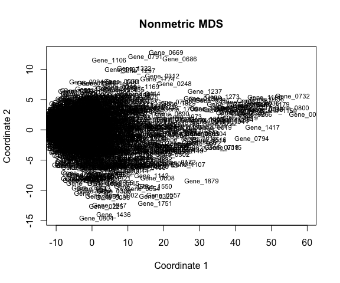

```r
feature_dist <- as.matrix(dist(exprs(example_sceset)))
featurePairwiseDistances(example_sceset) <- feature_dist

if(require(MASS)) {
    fit <- MASS::isoMDS(featDist(example_sceset), k=2) # k is the number of dim
    # plot solution
    x <- fit$points[,1]
    y <- fit$points[,2]
    plot(x, y, xlab="Coordinate 1", ylab="Coordinate 2", main="Nonmetric MDS",
         type="n")
    text(x, y, labels = rownames(example_sceset), cex=.7)
}
```

## Using **kallisto** to quantify transcript abundance from within R

Lior Pachter’s group at Berkeley has recently released a new software tool called **kallisto** for rapid quantification of transcript abundance from RNA-seq data. In `scater`, a couple of wrapper functions to `kallisto` enable easy and extremely fast quantification of transcript abundance from within R.

```r
################################################################################
### Tests and Examples

# Example if in the kallisto/test directory
setwd("/home/davis/kallisto/test")
kallisto_log <- runKallisto("targets.txt", "transcripts.idx", single_end=FALSE,
            output_prefix="output", verbose=TRUE, n_bootstrap_samples=10)

sce_test <- readKallistoResults(kallisto_log, read_h5=TRUE)
sce_test
```

An example using real data from a project investigating cell cycle. Not that this analysis is not ‘live’ (the raw data are not included in the package), but it demonstrates what can be done with `scater` and `kallisto`.

```r
setwd("/home/davis/021_Cell_Cycle/data/fastq")
system("wc -l targets.txt")
ave_frag_len <- mean(c(855, 860, 810, 760, 600, 690, 770, 690))

kallisto_test <- runKallisto("targets.txt",
                             "Mus_musculus.GRCm38.rel79.cdna.all.ERCC.idx",
                             output_prefix="kallisto_output_Mmus", n_cores=12,
                             fragment_length=ave_frag_len, verbose=TRUE)
sce_kall_mmus <- readKallistoResults(kallisto_test, read_h5=TRUE)
sce_kall_mmus

sce_kall_mmus <- readKallistoResults(kallisto_test)

sce_kall_mmus <- getBMFeatureAnnos(sce_kall_mmus)

head(fData(sce_kall_mmus))
head(pData(sce_kall_mmus))
sce_kall_mmus[["start_time"]]

counts(sce_kall_mmus)[sample(nrow(sce_kall_mmus), size=15), 1:6]

## Summarise expression at the gene level
sce_kall_mmus_gene <- summariseExprsAcrossFeatures(
    sce_kall_mmus, use_as_exprs="tpm", summarise_by="feature_id")

fData(sce_kall_mmus_gene) %>% datatable

sce_kall_mmus_gene <- getBMFeatureAnnos(
    sce_kall_mmus_gene, filters="ensembl_gene_id",
    attributes=c("ensembl_gene_id", "mgi_symbol", "chromosome_name",
                 "gene_biotype", "start_position", "end_position",
                 "percentage_gc_content", "description"),
    feature_symbol="mgi_symbol", feature_id="ensembl_gene_id",
    biomart="ensembl", dataset="mmusculus_gene_ensembl")

fData(sce_kall_mmus_gene) %>% datatable

## Add gene symbols to featureNames to make them more intuitive
new_feature_names <- featureNames(sce_kall_mmus_gene)
notna_mgi_symb <- !is.na(fData(sce_kall_mmus_gene)$mgi_symbol)
new_feature_names[notna_mgi_symb] <- fData(sce_kall_mmus_gene)$mgi_symbol[notna_mgi_symb]
notna_ens_gid <- !is.na(fData(sce_kall_mmus_gene)$ensembl_gene_id)
new_feature_names[notna_ens_gid] <- paste(new_feature_names[notna_ens_gid],
          fData(sce_kall_mmus_gene)$ensembl_gene_id[notna_ens_gid], sep="_")
sum(duplicated(new_feature_names))
featureNames(sce_kall_mmus_gene) <- new_feature_names
featureNames(sce_kall_mmus_gene) %>% head
featureNames(sce_kall_mmus_gene) %>% tail
sum(duplicated(fData(sce_kall_mmus_gene)$mgi_symbol))
```